# Assemblycomparator2 Report

2021-05-13

## Sample overview

|  | input_file | sample_raw | sample | extension | input_file_fasta |
| --- | --- | --- | --- | --- | --- |
| 1 | 116_2.fna | 116_2 | 116_2 | fna | output_asscom2/samples/116_2/116_2.fa |
| 2 | Dallas 55.fna | Dallas 55 | Dallas_55 | fna | output_asscom2/samples/Dallas_55/Dallas_55.fa |
| 3 | E8202.fna | E8202 | E8202 | fna | output_asscom2/samples/E8202/E8202.fa |
| 4 | EF_VRE.fna | EF_VRE | EF_VRE | fna | output_asscom2/samples/EF_VRE/EF_VRE.fa |
| 5 | ISMMS_VRE_1.fna | ISMMS_VRE_1 | ISMMS_VRE_1 | fna | output_asscom2/samples/ISMMS_VRE_1/ISMMS_VRE_1.fa |
| 6 | VB3240.fna | VB3240 | VB3240 | fna | output_asscom2/samples/VB3240/VB3240.fa |

## Assembly statistics

Assembly statistics is provided by assembly-stats.

|  | sample | total_length | number | mean_length | longest | shortest | N_count | Gaps | N50 | N50n | N70 | N70n | N90 | N90n |
| --- | --- | --- | --- | --- | --- | --- | --- | --- | --- | --- | --- | --- | --- | --- |
| 1 | 116_2 | 235063 | 3 | 78354.33 | 181744 | 21625 | 0 | 0 | 181744 | 1 | 181744 | 1 | 31694 | 2 |
| 2 | Dallas_55 | 310185 | 5 | 62037 | 202167 | 4374 | 0 | 0 | 202167 | 1 | 54822 | 2 | 36284 | 3 |
| 3 | E8202 | 262098 | 6 | 43683 | 188833 | 4203 | 0 | 0 | 188833 | 1 | 188833 | 1 | 11924 | 3 |
| 4 | EF_VRE | 317485 | 5 | 63497 | 240928 | 6173 | 0 | 0 | 240928 | 1 | 240928 | 1 | 18356 | 3 |
| 5 | ISMMS_VRE_1 | 128914 | 5 | 25782.8 | 57543 | 886 | 0 | 0 | 44226 | 2 | 44226 | 2 | 13123 | 4 |
| 6 | VB3240 | 266288 | 5 | 53257.6 | 258646 | 956 | 0 | 0 | 258646 | 1 | 258646 | 1 | 258646 | 1 |

Lengths of contigs:

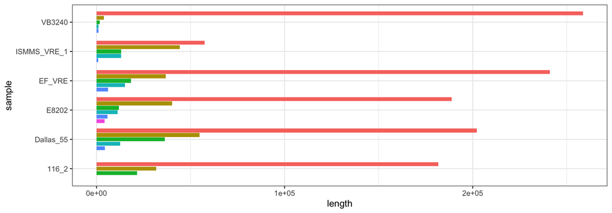

*Fig. 1: Lengths of contigs (fasta records) for each sample. The colors have no intrinsic meaning.*

## Species

Species identification is provided by [Kraken 2](https://github.com/DerrickWood/kraken2/wiki/About-Kraken-2).

|  | sample | percent_hit 1 | clade_hit 1 | percent_hit 2 | clade_hit 2 |
| --- | --- | --- | --- | --- | --- |
| 1 | 116_2 | 66.7 | Enterococcus faecium | 33.3 | Enterococcus faecalis |
| 2 | Dallas_55 | 100 | Enterococcus faecium |  |  |
| 3 | E8202 | 100 | Enterococcus faecium |  |  |
| 4 | EF_VRE | 100 | Enterococcus faecium |  |  |
| 5 | ISMMS_VRE_1 | 100 | Enterococcus faecium |  |  |
| 6 | VB3240 | 100 | Enterococcus faecium |  |  |

Using the /Users/reasonable/databases/kraken2/k2_standard_8gb_20201202 database.

## MLST

Multi locus sequence typing provided by mlst. The mlst software incorporates components of the [PubMLST](https://pubmlst.org/) database.

|  | sample | scheme | sequence_type |
| --- | --- | --- | --- |
| 1 | 116_2 | - | - |
| 2 | Dallas_55 | - | - |
| 3 | E8202 | - | - |
| 4 | EF_VRE | - | - |
| 5 | ISMMS_VRE_1 | - | - |
| 6 | VB3240 | - | - |

## NCBI Resistance

Resistance genes provided by [NCBI AMRFinder](https://www.ncbi.nlm.nih.gov/pmc/articles/PMC6811410/) via [Abricate](https://github.com/tseemann/abricate#abricate).

|  | sample | num_found | ant(6)-Ia | aph(2'')-Ih | aph(3')-IIIa | erm(B) | fosB3 | poxtA | sat4 | tet(L) | tet(M) | vanA | vanH-A | vanR-A | vanS-A | vanX-A | vanY-A | vanZ-A |
| --- | --- | --- | --- | --- | --- | --- | --- | --- | --- | --- | --- | --- | --- | --- | --- | --- | --- | --- |
| 1 | 116_2 | 4 | . | 88.70 | . | 100.00 | 100.00 | 100.00 | . | . | . | . | . | . | . | . | . | . |
| 2 | Dallas_55 | 12 | 100.00 | 89.15 | 100.00 | 100.00 | . | . | 100.00 | . | . | 100.00 | 100.00 | 100.00 | 100.00 | 100.00 | 100.00 | 100.00 |
| 3 | E8202 | 6 | . | . | . | 88.89 | . | . | . | . | . | 100.00 | 100.00 | 100.00 | 100.00 | 100.00 | . | . |
| 4 | EF_VRE | 9 | . | 89.15 | . | 100.00 | . | . | . | 100.00 | 100.00 | 100.00 | 100.00 | 100.00 | 100.00 | 100.00 | . | . |
| 5 | ISMMS_VRE_1 | 11 | 100.00 | . | 100.00 | 100.00 | . | . | 99.82 | . | . | 100.00 | 100.00 | 100.00 | 100.00 | 100.00 | 100.00 | 100.00 |
| 6 | VB3240 | 1 | . | 82.21;82.21;89.15 | . | . | . | . | . | . | . | . | . | . | . | . | . | . |

## Card Resistance genes

Resistance genes provided by The Comprehensive Antibiotic Resistance Database ([Card](https://card.mcmaster.ca/)) via abricate.

|  | sample | num_found | AAC(6')-Ie-APH(2'')-Ia | APH(3')-IIIa | ErmB | FosB3 | SAT-4 | aad(6) | poxtA | tet(L) | tetM | tetU | vanA | vanHA | vanRA | vanSA | vanXA | vanYA | vanZA |
| --- | --- | --- | --- | --- | --- | --- | --- | --- | --- | --- | --- | --- | --- | --- | --- | --- | --- | --- | --- |
| 1 | 116_2 | 4 | 99.51 | . | 99.87 | 100.00 | . | . | 100.00 | . | . | . | . | . | . | . | . | . | . |
| 2 | Dallas_55 | 12 | 91.04 | 100.00 | 99.87 | . | 100.00 | 100.00 | . | . | . | . | 100.00 | 100.00 | 100.00 | 100.00 | 100.00 | 100.00 | 100.00 |
| 3 | E8202 | 6 | . | . | 87.82 | . | . | . | . | . | . | . | 100.00 | 100.00 | 100.00 | 100.00 | 100.00 | . | . |
| 4 | EF_VRE | 9 | 100.00 | . | 99.87 | . | . | . | . | 100.00 | 100.00 | . | 100.00 | 100.00 | 100.00 | 100.00 | 100.00 | . | . |
| 5 | ISMMS_VRE_1 | 11 | . | 100.00 | 99.87 | . | 99.82 | 100.00 | . | . | . | . | 100.00 | 100.00 | 100.00 | 100.00 | 100.00 | 100.00 | 100.00 |
| 6 | VB3240 | 2 | 95.00;100.00 | . | . | . | . | . | . | . | . | 99.69;100.00 | . | . | . | . | . | . | . |

## Plasmidfinder calls

Plasmid calls provided by [PlasmidFinder](https://cge.cbs.dtu.dk/services/PlasmidFinder/) via abricate.

|  | sample | num_found | rep11a_1_repA(pB82) | rep14a_1_CDS2(pEFNP1) | rep14a_3_EFAU085p5001(AUS0085p5) | rep14a_4_rep(AUS0004p3) | rep14b_4_EMQU3221(pQY003) | rep17_1_CDS29(pRUM) | rep18a_1_repA(p200B) | rep18b_1_BO23315710(pE1p13) | rep1_9_repE(pKL0018) | rep29_2_EFAU085p4001(Aus0085p4)_Aus0085 | rep2_1_orf1(pRE25) | rep35_2_ORF2(pSMQ172) | repUS15_1_repA(DO3) | repUS15_2_repA(pNB2354p1) | repUS43_1_CDS12738(DOp1) | repUS57_1_rep(AUS0004p2) |
| --- | --- | --- | --- | --- | --- | --- | --- | --- | --- | --- | --- | --- | --- | --- | --- | --- | --- | --- |
| 1 | 116_2 | 3 | . | . | . | . | . | . | . | . | 100.00 | 99.86 | . | . | . | 100.00 | . | . |
| 2 | Dallas_55 | 4 | . | . | . | . | 97.56 | 100.00 | 100.00 | . | . | . | . | . | . | 100.00 | . | . |
| 3 | E8202 | 5 | . | . | . | . | . | . | . | 100.00 | . | 100.00 | 100.00 | 97.62 | 100.00 | . | . | . |
| 4 | EF_VRE | 4 | 100.00 | . | . | . | . | 100.00 | . | . | . | . | . | . | . | 100.00 | 100.00 | . |
| 5 | ISMMS_VRE_1 | 3 | . | . | 97.44 | . | . | 100.00 | 100.00;100.00 | . | . | . | . | . | . | . | . | . |
| 6 | VB3240 | 5 | . | 100.00 | . | 85.77 | 95.12 | . | . | . | . | . | . | . | . | 100.00 | . | 100.00 |

## VFDB calls

Virulence factor calls provided by The virulence factor database ([VFDB](http://www.mgc.ac.cn/VFs/main.htm)) via abricate. “An integrated and comprehensive online resource for curating information about virulence factors of bacterial pathogens.”

|  | sample | num_found |
| --- | --- | --- |

## Pan and Core genome

[Roary](https://sanger-pathogens.github.io/Roary/) the pan genome pipeline computes the number of orthologous genes in a number of core/pan partitions.

The core genome denotes the genes which are conserved between all samples (intersection), whereas the pan genome is the union of all genes across all samples.

| ortholog class | definition | count |
| --- | --- | --- |
| Core genes | (99% &lt;= strains &lt;= 100%) | 18 |
| Soft core genes | (95% &lt;= strains &lt; 99%) | 0 |
| Shell genes | (15% &lt;= strains &lt; 95%) | 923 |
| Cloud genes | (0% &lt;= strains &lt; 15%) | 0 |
| Total genes | (0% &lt;= strains &lt;= 100%) | 941 |

*Table 1: Distribution of genes in different core/pan partitions.*

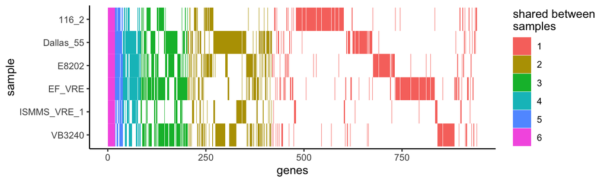

*Fig. 2: Visual distribution of genes in the different samples. The genes are ordered in respect to the number of samples sharing them.*

## Core genome phylogeny

The core genome phylogeny is provided with [FastTree](http://www.microbesonline.org/fasttree/) with the generalized time-reversible (GTR) model of nucleotide evolution. The plotted tree is midpoint rooted.

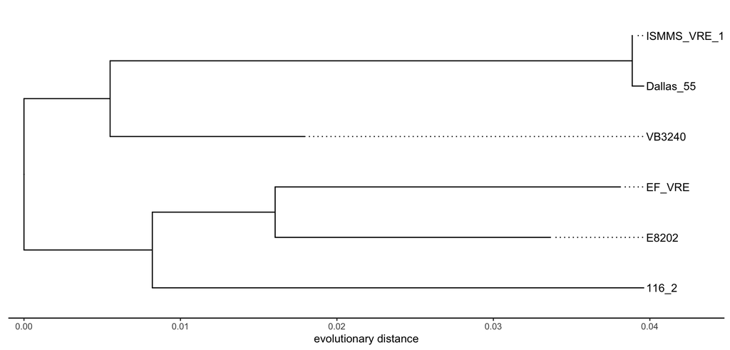

The assemblycomparator2 pipeline and this report is developed by Oliver Hansen & Carl M. Kobel